# Membangkitkan Model AR, MA, dan ARMA

Nabil Naufal (G1401211008)

# Proses MA

Proses MA dapat dituliskan sebagai berikut:

$$y_{t} = c + e_t + \theta_{1}e_{t-1} + \theta_{2}e_{t-2} + \dots +
\theta_{q}e_{t-q} = c+{e_t+\sum_{i=1}^p \theta_ie_{t-i}}$$
Terlihat bahwa $e_t$, atau *white noise*, berperan penting dalam pembangkitan proses MA.

## Membangkitkan white noise

```r
set.seed(008)
wn <- rnorm(300)
ma2 = wn[c(1,2)]
```

## MA(2) dengan $\theta_1 = 0.4$ dan $\theta_2 = 0.6$

$ Y_t = e_t+0.4e_{t-1}+0.6e_{t-2}$

```r
for(i in 3:300){
   ma2[i] <- wn[i] + 0.4 * wn[i - 1] +  0.6 * wn[i - 2]
}
ma2
```

```
##   [1] -0.084586071  0.840400126 -0.178074365 -0.231988038  0.237616767
##   [6] -0.143966231  0.228182549 -1.221176213 -3.548557850 -2.450594030
##  [11] -2.803694535 -0.367772255  0.082342262 -0.950699725 -0.195671387
##  [16] -1.562017890  1.227208735 -0.155090737  2.356122220  0.222986373
##  [21]  2.123135291  0.361349595  0.365995093 -0.143741270  1.511511962
##  [26] -0.396875833 -0.457698717  0.862661031  0.746877581 -0.608829992
##  [31]  1.060055796  0.354015618 -0.264401651 -0.816972290  0.018986157
##  [36]  0.468581534  1.772432622 -0.104243670  0.162227625  0.025548404
##  [41]  0.512976714 -0.186565473  0.201227300 -0.539210663  0.645102831
##  [46] -1.869824197 -1.079018874 -1.156182969 -0.015871513 -0.362345046
##  [51]  0.985140148 -0.317228679  1.091277613 -0.079437596  1.286688610
##  [56]  0.909414479  0.037118728 -0.564630150 -2.205960357 -0.206069608
##  [61] -0.040631951  0.770292931 -1.409113963 -1.764442693 -1.779829598
##  [66] -1.848907645 -1.082281618  0.796745452  0.757765179 -0.455843795
##  [71] -1.868853325 -0.505782218  0.318272041  0.460118708  0.372884666
```

[output cut: 45 more lines]

Selain menggunakan cara di atas, pembangkitan proses MA(2) dapat dilakukan dengan fungsi `arima.sim()` sebagai berikut.

```r
set.seed(008)
ma2. <- arima.sim(list(order=c(0,0,2), ma=c(0.4,0.6)), n=300)
ma2.
```

```
## Time Series:
## Start = 1
## End = 300
## Frequency = 1
##   [1] -0.178074365 -0.231988038  0.237616767 -0.143966231  0.228182549
##   [6] -1.221176213 -3.548557850 -2.450594030 -2.803694535 -0.367772255
##  [11]  0.082342262 -0.950699725 -0.195671387 -1.562017890  1.227208735
##  [16] -0.155090737  2.356122220  0.222986373  2.123135291  0.361349595
##  [21]  0.365995093 -0.143741270  1.511511962 -0.396875833 -0.457698717
##  [26]  0.862661031  0.746877581 -0.608829992  1.060055796  0.354015618
##  [31] -0.264401651 -0.816972290  0.018986157  0.468581534  1.772432622
##  [36] -0.104243670  0.162227625  0.025548404  0.512976714 -0.186565473
##  [41]  0.201227300 -0.539210663  0.645102831 -1.869824197 -1.079018874
##  [46] -1.156182969 -0.015871513 -0.362345046  0.985140148 -0.317228679
##  [51]  1.091277613 -0.079437596  1.286688610  0.909414479  0.037118728
```

[output cut: 49 more lines]

## Karakteristik MA(2)

### Plot Time Series

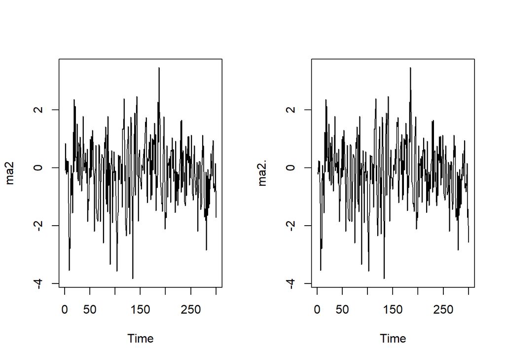

```r
par(mfrow = c(1, 2))
ts.plot(ma2)
ts.plot(ma2.)
```

Berdasarkan plot time series, terlihat bahwa data MA(2) yang dibangkitkan stasioner dalam rataan

### Plot ACF

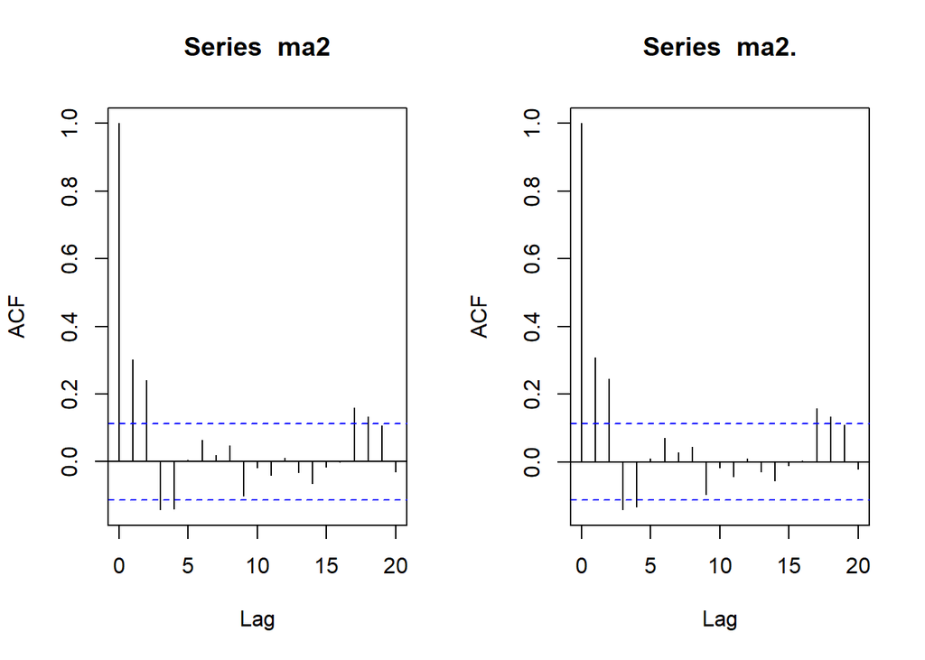

```r
par(mfrow = c(1, 2))
acf(ma2,lag.max = 20)
acf(ma2.,lag.max = 20)
```

### Plot PACF

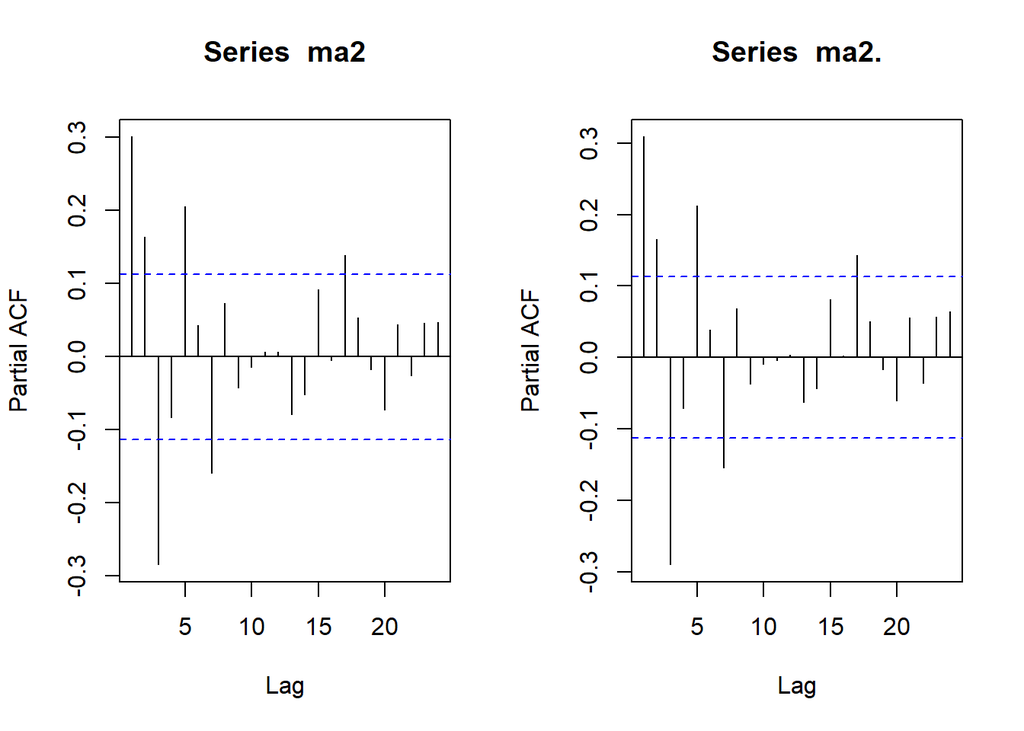

```r
par(mfrow = c(1, 2))
pacf(ma2)
pacf(ma2.)
```

Berdasarkan plot PACF tersebut, terlihat bahwa plot PACF cenderung *tails off* dan membentuk gelombang sinus

### Plot EACF

```r
TSA::eacf(ma2)
```

```
## AR/MA
##   0 1 2 3 4 5 6 7 8 9 10 11 12 13
## 0 x x x x o o o o o o o  o  o  o
## 1 x x x x o o o o o o o  o  o  o
## 2 x x o o o x o o x o o  o  o  o
## 3 x x o o o o o o x o o  o  o  o
## 4 x x x o o o o o o o o  o  o  o
## 5 x x o o o o x o o o o  o  o  o
## 6 x x x o o o o o o o o  o  o  o
## 7 x o x o o x o o x o o  o  o  o
```

```r
TSA::eacf(ma2.)
```

```
## AR/MA
##   0 1 2 3 4 5 6 7 8 9 10 11 12 13
## 0 x x x x o o o o o o o  o  o  o
## 1 x x x x o o o o o o o  o  o  o
## 2 x x o o o x o o x o o  o  o  o
## 3 x x x o o o o o x o o  o  o  o
## 4 x x x o o o o o o o o  o  o  o
## 5 x x o o o o x o o o o  o  o  o
## 6 x x x o o o o o o o o  o  o  o
## 7 x o x o o x o o x o o  o  o  o
```

### Scatterplot Antar Lag

#### Korelasi antara $Y_t$ dengan $Y_{t-1}$

```r
#Yt
yt_ma <- ma2[-1]
yt_ma. <- ma2.[-1]

#Yt-1
yt_1_ma <- ma2[-300]
yt_1_ma. <- ma2.[-300]
```

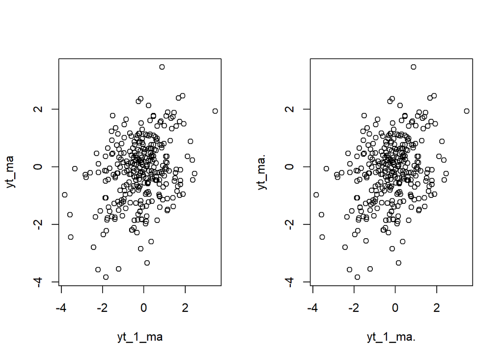

```r
par(mfrow = c(1, 2))
plot(y=yt_ma,x=yt_1_ma)
plot(y=yt_ma.,x=yt_1_ma.)
```

Berdasarkan scatterplot tersebut, terlihat bahwa terdapat hubungan positif antara $Y_t$ dengan $Y_{t-1}$. Hal ini sesuai dengan teori yang ada

```r
cor(yt_ma,yt_1_ma)
```

```
## [1] 0.3018363
```

```r
cor(yt_ma.,yt_1_ma.)
```

```
## [1] 0.3111507
```

#### Korelasi antara $Y_t$ dengan $Y_{t-2}$

```r
#Yt
yt_ma2 <- ma2[-c(1,2)]
yt_ma2. <- ma2.[-c(1,2)]

#Yt-2
yt_2_ma <- ma2[-c(199,200)]
yt_2_ma. <- ma2.[-c(199,200)]
```

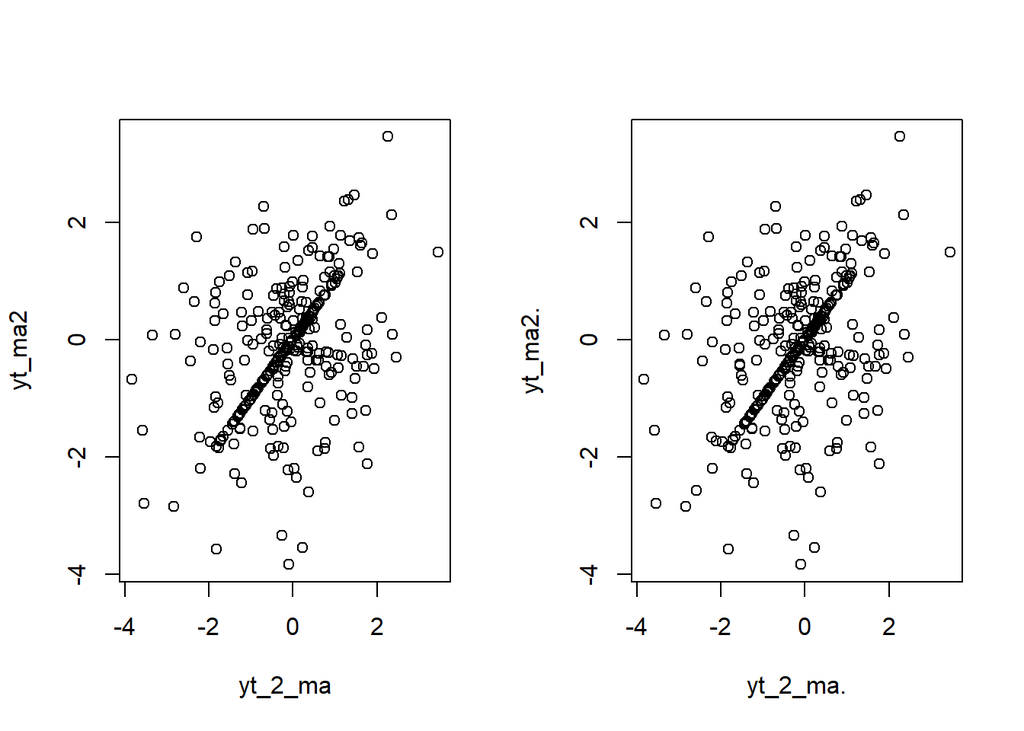

```r
par(mfrow = c(1, 2))
plot(y=yt_ma2,x=yt_2_ma)
plot(y=yt_ma2.,x=yt_2_ma.)
```

```r
cor(yt_ma2,yt_2_ma)
```

```
## [1] 0.3739548
```

```r
cor(yt_ma2.,yt_2_ma.)
```

```
## [1] 0.3876107
```

#### Korelasi antara $Y_t$ dengan $Y_{t-3}$

```r
#Yt
yt_ma3<- ma2[-c(1,2,3)]
yt_ma3.<- ma2.[-c(1,2,3)]

#Yt-3
yt_3_ma <- ma2[-c(288,299,300)]
yt_3_ma. <- ma2.[-c(288,299,300)]
```

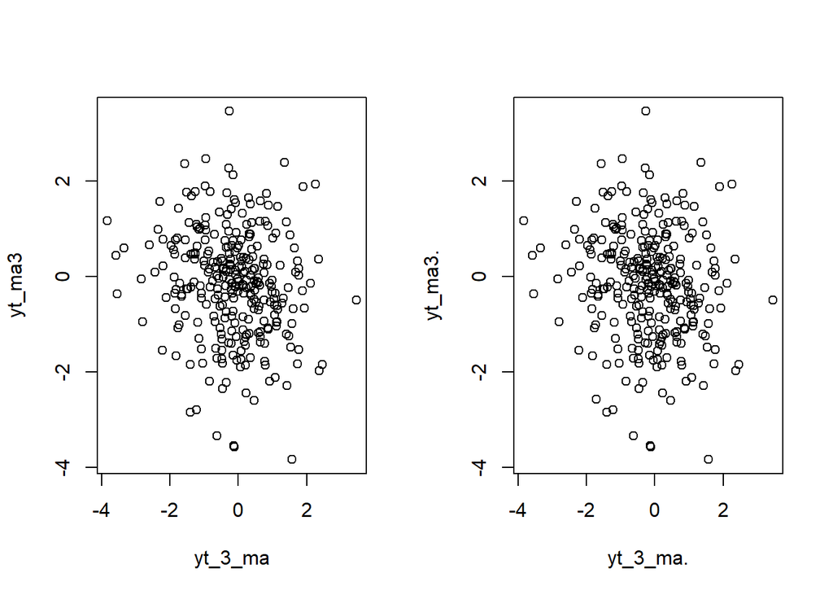

```r
par(mfrow=c(1,2))
plot(y=yt_ma3,x=yt_3_ma)
plot(y=yt_ma3.,x=yt_3_ma.)
```

Berdasarkan scatterplot tersebut, terlihat bahwa cenderung tidak terdapat hubungan antara $Y_t$ dengan $Y_{t-3}$.

```r
par(mfrow=c(1,2))
cor(yt_ma3,yt_3_ma)
```

```
## [1] -0.1449357
```

```r
cor(yt_ma3.,yt_3_ma.)
```

```
## [1] -0.1350934
```

Korelasi antara $Y_t$ dengan $Y_{t-3}$ hasil simulasi mendekati teori yang ada yaitu 0.

# Proses AR

$$Y_t = e_t+0.5Y_{t-1}+0.2Y_{t-2}$$

```r
set.seed(008)
wn = rnorm(300)

n<-length(wn)
n
```

```
## [1] 300
```

```r
ar2 <- c(1:n)
for (i in 3:n) {ar2[i]<-wn[i]+0.5*ar2[i-1]+0.2*ar2[i-2]}
ar2
```

```
##   [1]  1.000000000  2.000000000  0.736517228  0.217423609  0.992055682
##   [6]  0.431631162  0.243937567 -0.880036696 -3.402282510 -2.470322927
##  [11] -2.675411762 -1.539720603 -0.883544059 -2.044205231 -1.129526339
##  [16] -1.786642693  0.391626458 -0.433124189  1.420017126  0.386033855
##  [21]  1.760143235  0.947788753  0.425840242  0.424463495  2.040167177
##  [26] -0.002197872 -0.653554983  1.623944254  1.283967873 -1.053836694
##  [31]  1.236550771  1.371219136 -0.620971690 -0.809884397  0.731641419
##  [36]  0.632299609  1.307061625  0.080840182  0.236970140  0.605636752
##  [41]  0.713713025 -0.136572046  0.303405872 -0.137668307  0.604403012
##  [46] -1.682944648 -1.384099193 -0.744851011 -0.380527381 -0.979338633
##  [51]  0.514176474 -0.303925830  0.540237769  0.113237771  1.136174195
##  [56]  1.169203596  0.034663134 -0.349669829 -1.667221697 -0.149381390
##  [61]  0.149159291  0.139580513 -1.681819302 -1.921785962 -1.564704623
##  [66] -2.243362588 -1.925773934  0.227638504  0.125441478 -1.489824953
##  [71] -2.187514356 -0.351584281  0.169535979 -0.462645287 -0.103390808
```

[output cut: 45 more lines]

Selain menggunakan cara di atas, pembangkitan proses AR dapat dilakukan dengan fungsi `arima.sim()` sebagai berikut.

```r
set.seed(008)
ar2. <- arima.sim(list(order=c(2,0,0), ar=c(0.5,0.2)), n=300)
ar2.
```

```
## Time Series:
## Start = 1
## End = 300
## Frequency = 1
##   [1] -0.003839880 -0.654806764  1.622989962  1.283240371 -1.054391303
##   [6]  1.236127965  1.370896811 -0.621217414 -0.810071723  0.731498611
##  [11]  0.632190740  1.306978629  0.080776910  0.236921904  0.605599980
##  [16]  0.713684992 -0.136593417  0.303389580 -0.137680727  0.604393543
##  [21] -1.682951866 -1.384104696 -0.744855206 -0.380530579 -0.979341071
##  [26]  0.514174615 -0.303927247  0.540236689  0.113236948  1.136173567
##  [31]  1.169203118  0.034662769 -0.349670108 -1.667221909 -0.149381552
##  [36]  0.149159168  0.139580419 -1.681819374 -1.921786016 -1.564704665
##  [41] -2.243362620 -1.925773958  0.227638486  0.125441464 -1.489824964
##  [46] -2.187514364 -0.351584287  0.169535975 -0.462645291 -0.103390811
##  [51]  0.454754891 -2.690598685 -0.670651672  1.502637795 -0.029073498
```

[output cut: 49 more lines]

## Karakteristik AR(2)

### Plot Time Series

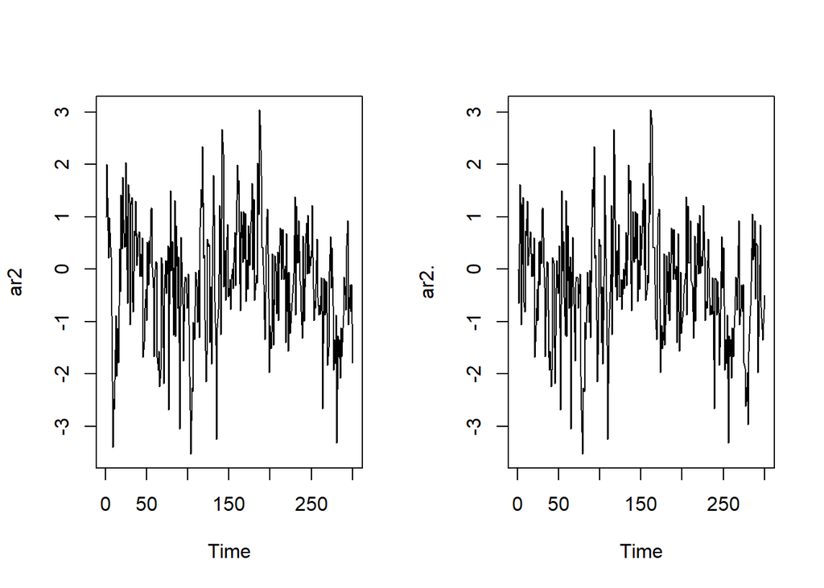

```r
par(mfrow=c(1,2))
ts.plot(ar2)
ts.plot(ar2.)
```

### Plot ACF

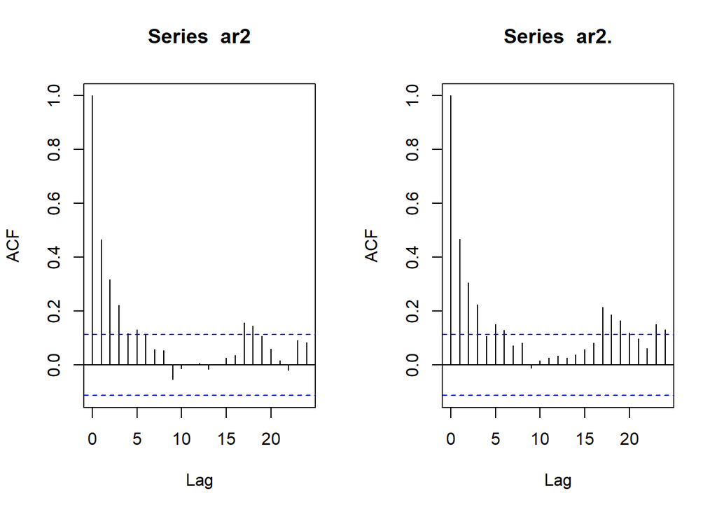

```r
par(mfrow=c(1,2))
acf(ar2)
acf(ar2.)
```

Berdasarkan plot ACF tersebut terlihat bahwa plot ACF cenderung *tails off* dan cenderung membentuk pola grafik sinus

### Plot PACF

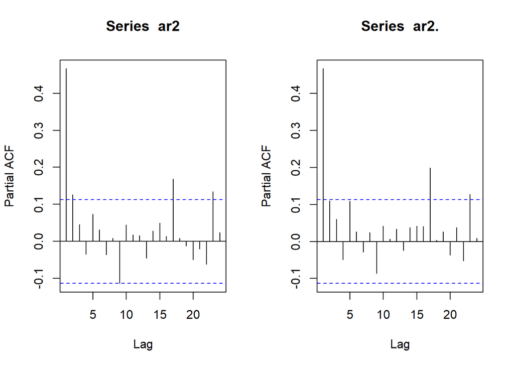

```r
par(mfrow=c(1,2))
pacf(ar2)
pacf(ar2.)
```

Berdasarkan plot PACF tersebut, terlihat bahwa plot PACF *cuts off* pada lag kedua, sejalan dengan teori yang ada

### Plot EACF

```r
par(mfrow=c(1,2))
TSA::eacf(ar2)
```

```
## AR/MA
##   0 1 2 3 4 5 6 7 8 9 10 11 12 13
## 0 x x x x x o o o o o o  o  o  o
## 1 x o o o o o o o o o o  o  o  o
## 2 x o o x o o o o o o o  o  o  o
## 3 x o o o o o o o o o o  o  o  o
## 4 x x x o o o o o o o o  o  o  o
## 5 x x x o x o o o o o o  o  o  o
## 6 x x o x o o o o o o o  o  o  o
## 7 o x x x x o o o o o o  o  o  o
```

```r
TSA::eacf(ar2.)
```

```
## AR/MA
##   0 1 2 3 4 5 6 7 8 9 10 11 12 13
## 0 x x x o x x o o o o o  o  o  o
## 1 x o o x o o o o o o o  o  o  o
## 2 x x o x o o o o o o o  o  o  o
## 3 x x o x o o o o o o o  o  o  o
## 4 x x x x o o o o o o o  o  o  o
## 5 x x x x x o o o o o o  o  o  o
## 6 x o o x o o o o o o o  o  o  o
## 7 x o o x o o o o o o o  o  o  o
```

### Scatterplot Antar Lag

#### Korelasi antara $Y_t$ dengan $Y_{t-1}$

```r
#Yt
yt_ar <- ar2[-1]
yt_ar. <- ar2.[-1]

#Yt-1
yt_1_ar <- ar2[-300]
yt_1_ar. <- ar2.[-300]
```

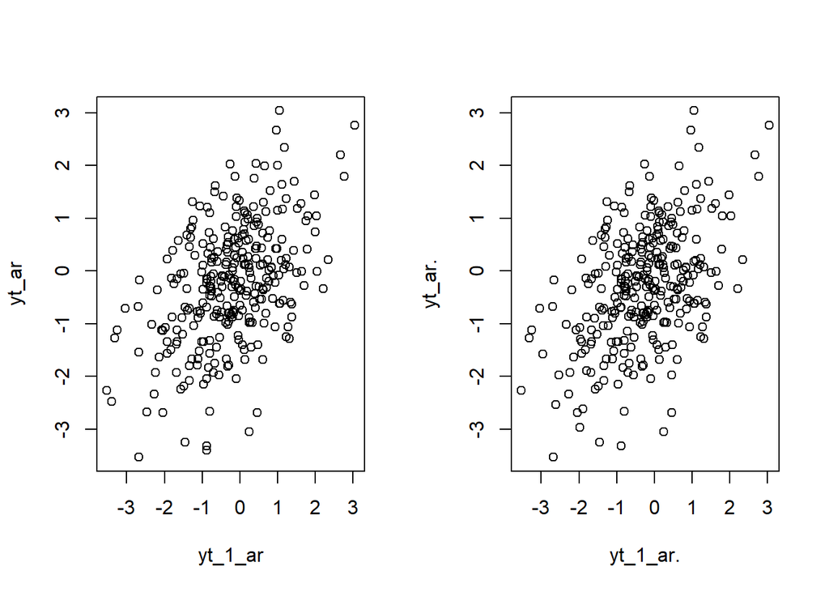

```r
par(mfrow=c(1,2))
plot(y=yt_ar,x=yt_1_ar)
plot(y=yt_ar.,x=yt_1_ar.)
```

Berdasarkan scatterplot tersebut, terlihat bahwa terdapat hubungan positif antara $Y_t$ dengan $Y_{t-1}$. Hal ini sesuai dengan teori yang ada

```r
cor(yt_ar,yt_1_ar)
```

```
## [1] 0.46873
```

```r
cor(yt_ar.,yt_1_ar.)
```

```
## [1] 0.4669156
```

#### Korelasi antara $Y_t$ dengan $Y_{t-2}$

```r
#Yt
yt_ar2 <- ar2[-c(1,2)]
yt_ar2. <- ar2.[-c(1,2)]

#Yt-2
yt_2_ar <- ar2[-c(199,200)]
yt_2_ar. <- ar2.[-c(199,200)]
```

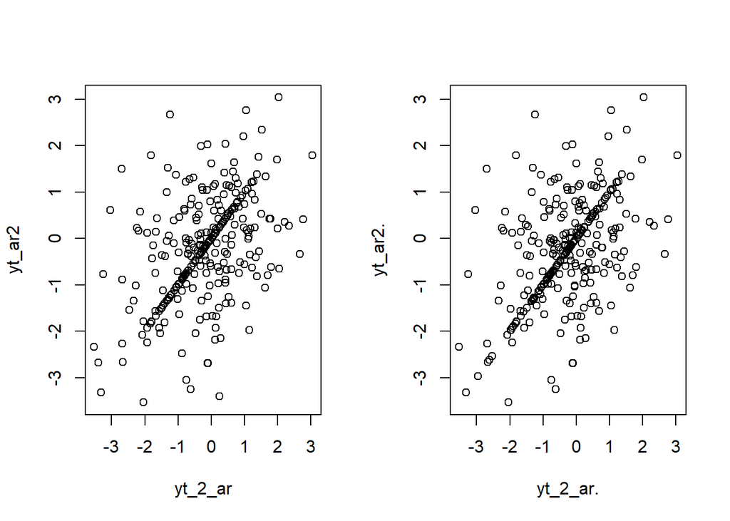

```r
par(mfrow=c(1,2))
plot(y=yt_ar2,x=yt_2_ar)
plot(y=yt_ar2.,x=yt_2_ar.)
```

Berdasarkan scatterplot tersebut, terlihat bahwa terdapat hubungan positif antara $Y_t$ dengan $Y_{t-2}$. Hal ini sesuai dengan teori yang ada

```r
cor(yt_ar2,yt_2_ar)
```

```
## [1] 0.4547448
```

```r
cor(yt_ar2.,yt_2_ar.)
```

```
## [1] 0.466182
```

#### Korelasi antara $Y_t$ dengan $Y_{t-3}$

```r
#Yt
yt_ar3 <- ar2[-c(1,2,3)]
yt_ar3. <- ar2.[-c(1,2,3)]

#Yt-3
yt_3_ar <- ar2[-c(198,199,200)]
yt_3_ar. <- ar2.[-c(198,199,200)]
```

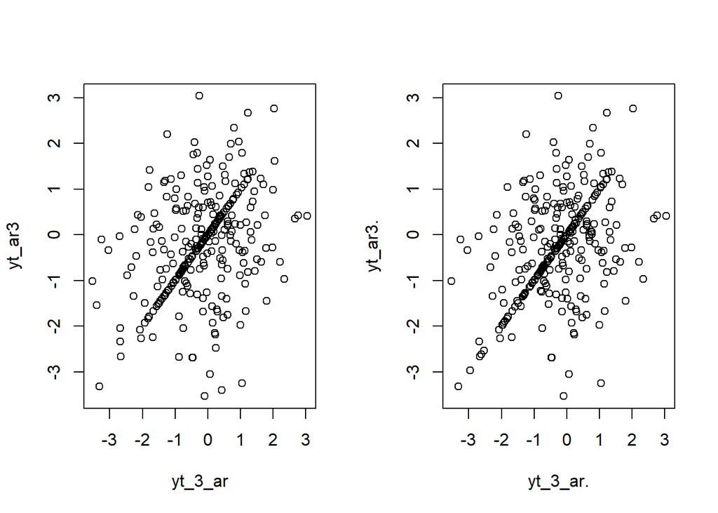

```r
par(mfrow=c(1,2))
plot(y=yt_ar3,x=yt_3_ar)
plot(y=yt_ar3.,x=yt_3_ar.)
```

Berdasarkan scatterplot tersebut, terlihat bahwa terdapat hubungan positif antara $Y_t$ dengan $Y_{t-3}$. Hal ini sesuai dengan teori yang ada

```r
cor(yt_ar3,yt_3_ar)
```

```
## [1] 0.3587565
```

```r
cor(yt_ar3.,yt_3_ar.)
```

```
## [1] 0.401311
```

# Proses ARMA

## Fungsi pembangkitan ARMA

```r
arma.sim <- function(n, macoef, arcoef){
  manum <- length(macoef)
  arnum <- length(arcoef)
  stopifnot(manum < n & arnum < n)

  wn <- rnorm(n, sd = 0.5)
  init <- max(manum, arnum)

  arma <- wn[1:init]
  for(i in {init+1}:n){
   mastart <- i - manum
   maend <- i-1
   arstart <- i - arnum
   arend <- i-1
   arma[i] <- sum(arcoef * arma[arstart:arend]) + sum(macoef * wn[mastart:maend])  + wn[i]
   }
  return(arma)
}
```

Terlihat bahwa komponen $\sum_{i=1}^q y_{t-1}$ disimulasikan melalui `sum(arcoef * arma[arstart:arend])`. Jadi, koefisien dikalikan dengan data $y$ dari $t-q$ di mana q adalah jumlah koefisien AR, sampai data $t-1$. Lalu komponen $\sum_{j=1}^q e_{t-j}$ disimulasikan melalui `sum(macoef * wn[mastart:maend])`. Koefisien dikalikan dengan *white noise* $e$ dari $t-p$, p jumlah koefisien MA, sampai $t-1$.

## Membangkitkan Model ARMA(2,2)

```r
set.seed(008)
arma22 <- arma.sim(n=300, arcoef = c(0.5, 0.2), macoef = c(0.4,0.6))
```

## Membangkitkan Data Secara Manual

```r
set.seed(008)
wn = rnorm(300)
n = length(wn)
phi1 = 0.5
phi2 = 0.2
theta1 = 0.4
theta2 = 0.6

arma22=c(1:n)
for (i in 3:n){arma22[i] = phi1*arma22[i-1] + phi2*arma22[i-2]  + theta1*wn[i-1] + theta2*wn[i-2] +wn[i]}
```

Pembangkitan ARMA(p,q) juga dapat dilakukan dengan fungsi `arima.sim` sebagai berikut.

```r
set.seed(008)
arma22. <- arima.sim(list(order=c(2,0,2), ar = c(0.5,0.2), ma = c(0.4,0.6)), n=300)
arma22.
```

```
## Time Series:
## Start = 1
## End = 300
## Frequency = 1
##   [1]  1.35828691  1.53918910  0.43242194  1.58410459  1.23255230  0.66869542
##   [7] -0.23611412  0.03466818  0.43869280  1.99871266  0.98285122  1.05339577
##  [13]  0.74881653  1.09806413  0.51222990  0.67695508 -0.09828715  0.73135027
##  [19] -1.52380649 -1.69465206 -2.30827030 -1.50893708 -1.57846764 -0.10588109
##  [25] -0.68586275  0.72717002  0.14697486  1.50561005  1.69161447  1.18404797
##  [31]  0.36571673 -1.78629240 -1.02607246 -0.91092666  0.10961511 -1.53649174
##  [37] -2.51076554 -3.34251072 -4.02231611 -3.76194182 -1.88868868 -0.93896752
##  [43] -1.30306529 -2.70817948 -2.12048501 -1.28360636 -0.60578148 -0.18672734
##  [49]  0.13581139 -2.57073122 -1.47403821 -0.37998209  0.16959062  1.41901307
##  [55] -0.33659820 -1.14815181  0.49203612 -1.50332269  1.11625996 -0.36094502
##  [61] -0.21773451 -0.01778267 -3.39729596 -1.77777151 -1.50032545 -0.51916624
```

[output cut: 39 more lines]

## Karakteristik ARMA(2,2)

### Plot Time Series

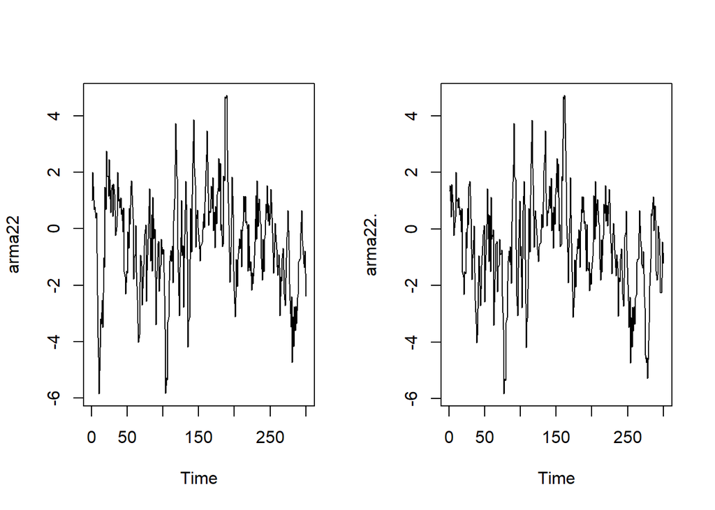

```r
par(mfrow = c(1, 2))
ts.plot(arma22)
ts.plot(arma22.)
```

Berdasarkan plot time series tersebut, terlihat bahwa model ARMA(2,2) cenderung stasioner dalam rataan

### Plot ACF

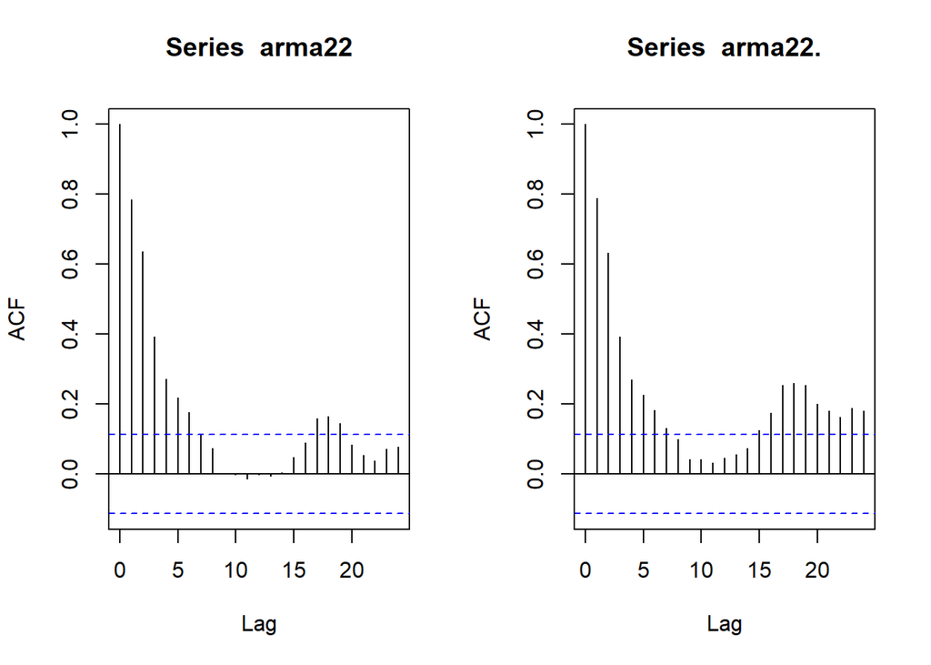

```r
par(mfrow = c(1, 2))
acf(arma22)
acf(arma22.)
```

Berdasarkan plot ACF tersebut, terlihat bahwa model ARMA(2,2) hasil simulasi memiliki plot ACF yang *tails off*, sesuai dengan teori yang ada

### Plot PACF

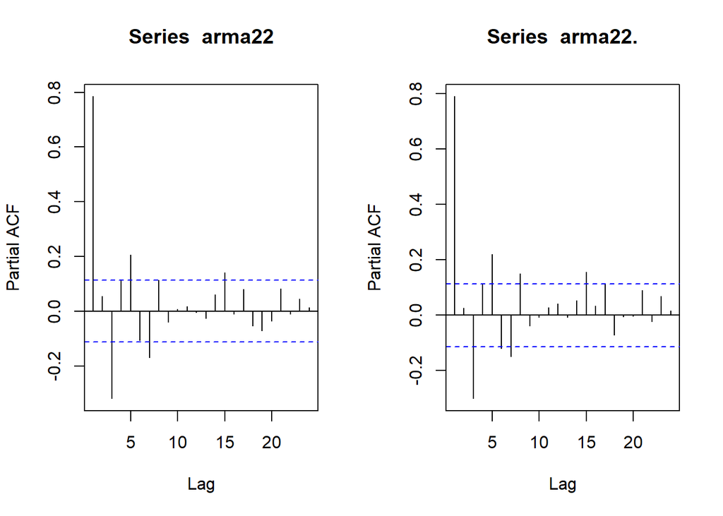

```r
par(mfrow = c(1, 2))
pacf(arma22)
pacf(arma22.)
```

Berdasarkan plot PACF tersebut, terlihat bahwa model ARMA(2,2) hasil simulasi memiliki plot PACF yang *tails off*, sesuai dengan teori

### Plot EACF

```r
TSA::eacf(arma22)
```

```
## AR/MA
##   0 1 2 3 4 5 6 7 8 9 10 11 12 13
## 0 x x x x x x o o o o o  o  o  o
## 1 o x x o o o o o o o o  o  o  o
## 2 x x x x o o o o o o o  o  o  o
## 3 x x x x o o o o o o o  o  o  o
## 4 x x x o o o o o o o o  o  o  o
## 5 x x o o o x o o o o o  o  o  o
## 6 x x o x x x o o o o o  o  o  o
## 7 x o o o o o o o x o o  o  o  o
```

```r
TSA::eacf(arma22.)
```

```
## AR/MA
##   0 1 2 3 4 5 6 7 8 9 10 11 12 13
## 0 x x x x x x x o o o o  o  o  o
## 1 o x o x o o o o x o o  o  o  o
## 2 o x x x o o o o x o o  o  o  o
## 3 x x x o o o o o o o o  o  o  o
## 4 x x o o o o o o x o o  o  o  o
## 5 x x x o o o o o x o o  o  o  o
## 6 x x o o o o x o o o o  o  o  o
## 7 x x x o o o o o x o o  o  o  o
```

### Scatterplot Antar Lag

#### Korelasi antara $Y_t$ dengan $Y_{t-1}$

```r
#Yt
yt_arma <- arma22[-1]
yt_arma. <- arma22.[-1]

#Yt-1
yt_1_arma <- arma22[-300]
yt_1_arma. <- arma22.[-300]
```

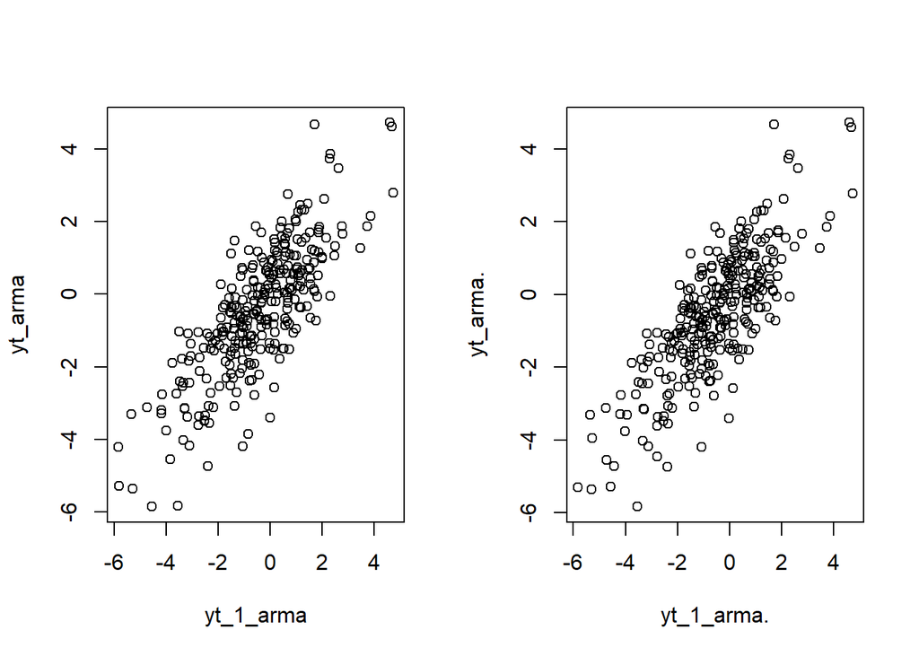

```r
par(mfrow=c(1,2))
plot(y=yt_arma,x=yt_1_arma)
plot(y=yt_arma.,x=yt_1_arma.)
```

Berdasarkan scatterplot tersebut, terlihat bahwa terdapat hubungan positif antara $Y_t$ dengan $Y_{t-1}$. Hal ini sesuai dengan teori yang ada

```r
cor(yt_arma,yt_1_arma)
```

```
## [1] 0.7873047
```

```r
cor(yt_arma.,yt_1_arma.)
```

```
## [1] 0.7906126
```

#### Korelasi antara $Y_t$ dengan $Y_{t-2}$

```r
#Yt
yt_arma2 <- arma22[-c(1,2)]
yt_arma2. <- arma22.[-c(1,2)]

#Yt-2
yt_2_arma <- arma22[-c(299,300)]
yt_2_arma. <- arma22.[-c(299,300)]
```

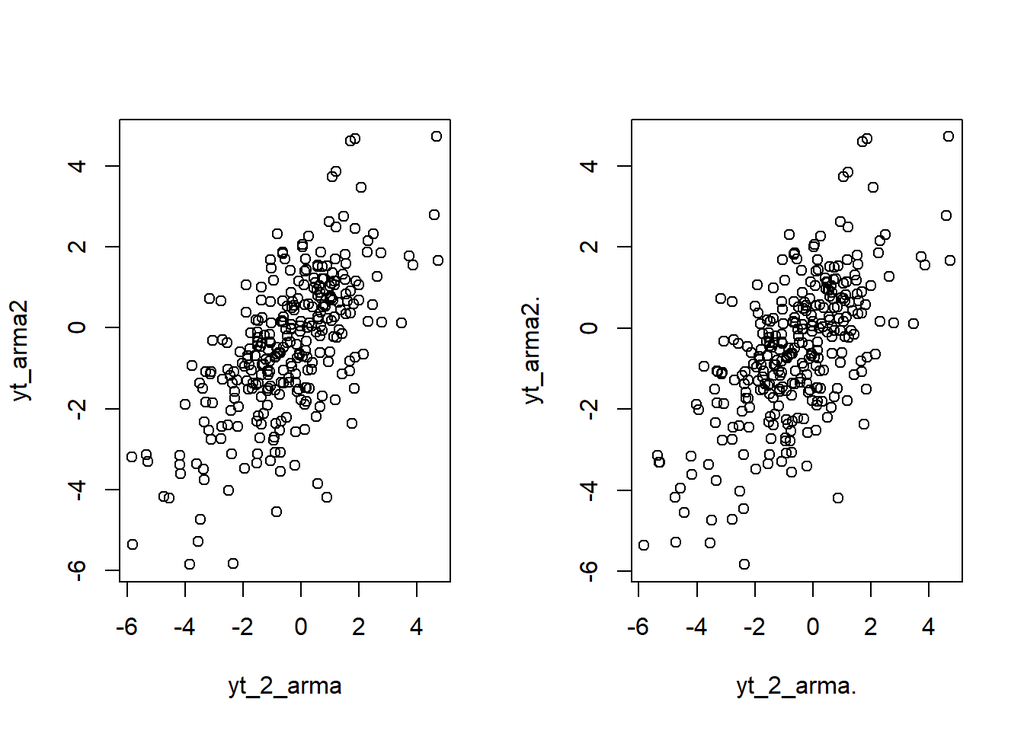

```r
par(mfrow=c(1,2))
plot(y=yt_arma2,x=yt_2_arma)
plot(y=yt_arma2.,x=yt_2_arma.)
```

Berdasarkan scatterplot tersebut, terlihat bahwa terdapat hubungan positif antara $Y_t$ dengan $Y_{t-2}$. Hal ini sesuai dengan teori yang ada

```r
cor(yt_arma2,yt_2_arma)
```

```
## [1] 0.6408944
```

```r
cor(yt_arma2.,yt_2_arma.)
```

```
## [1] 0.6348718
```

#### Korelasi antara $Y_t$ dengan $Y_{t-3}$

```r
#Yt
yt_arma3 <- arma22[-c(1,2,3)]
yt_arma3. <- arma22.[-c(1,2,3)]

#Yt-3
yt_3_arma <- arma22[-c(298,299,300)]
yt_3_arma. <- arma22.[-c(298,299,300)]
```

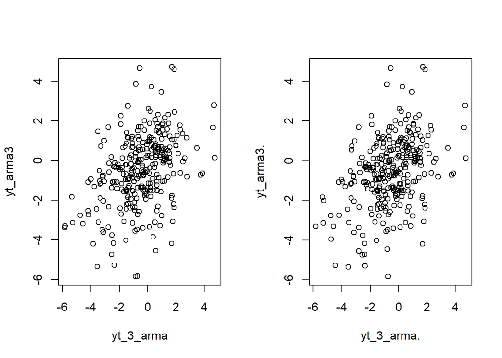

```r
par(mfrow=c(1,2))
plot(y=yt_arma3,x=yt_3_arma)
plot(y=yt_arma3.,x=yt_3_arma.)
```

```r
cor(yt_arma3,yt_3_arma)
```

```
## [1] 0.3962797
```

```r
cor(yt_arma3.,yt_3_arma.)
```

```
## [1] 0.3947975
```